# Churn Prediction for Customers in the Telecom Industry

[figure not shown]

## About the Dataset

Each row represents a customer, each column contains customer’s attributes described on the column Metadata.

**The data set includes information about:**

**Customers who left within the last month** – the column is called Churn

**Services that each customer has signed up for** – phone, multiple lines, internet, online security, online backup, device protection, tech support, and streaming TV and movies

**Customer account information** – how long they’ve been a customer, contract, payment method, paperless billing, monthly charges, and total charges

**Demographic info about customers** – gender, age range, and if they have partners and dependents

## The Mission

Explore the Dataset and create a model to predict if a customer is going to churn or not

### Let's get started

```python
#importing Libraries

import pandas as pd
import numpy as np
import seaborn as sns
import matplotlib as mpl
import matplotlib.pyplot as plt
```

```python
#reading the data

cust = pd.read_csv('WA_Fn-UseC_-Telco-Customer-Churn.csv')
```

```python
cust.head()
```

|  | customerID | gender | SeniorCitizen | Partner | Dependents | tenure | PhoneService | MultipleLines | InternetService | OnlineSecurity | ... | DeviceProtection | TechSupport | StreamingTV | StreamingMovies | Contract | PaperlessBilling | PaymentMethod | MonthlyCharges | TotalCharges | Churn |
| --- | --- | --- | --- | --- | --- | --- | --- | --- | --- | --- | --- | --- | --- | --- | --- | --- | --- | --- | --- | --- | --- |
| 0 | 7590-VHVEG | Female | 0 | Yes | No | 1 | No | No phone service | DSL | No | ... | No | No | No | No | Month-to-month | Yes | Electronic check | 29.85 | 29.85 | No |
| 1 | 5575-GNVDE | Male | 0 | No | No | 34 | Yes | No | DSL | Yes | ... | Yes | No | No | No | One year | No | Mailed check | 56.95 | 1889.5 | No |
| 2 | 3668-QPYBK | Male | 0 | No | No | 2 | Yes | No | DSL | Yes | ... | No | No | No | No | Month-to-month | Yes | Mailed check | 53.85 | 108.15 | Yes |
| 3 | 7795-CFOCW | Male | 0 | No | No | 45 | No | No phone service | DSL | Yes | ... | Yes | Yes | No | No | One year | No | Bank transfer (automatic) | 42.30 | 1840.75 | No |
| 4 | 9237-HQITU | Female | 0 | No | No | 2 | Yes | No | Fiber optic | No | ... | No | No | No | No | Month-to-month | Yes | Electronic check | 70.70 | 151.65 | Yes |

5 rows × 21 columns

```python
cust.columns
```

```
Index(['customerID', 'gender', 'SeniorCitizen', 'Partner', 'Dependents',
       'tenure', 'PhoneService', 'MultipleLines', 'InternetService',
       'OnlineSecurity', 'OnlineBackup', 'DeviceProtection', 'TechSupport',
       'StreamingTV', 'StreamingMovies', 'Contract', 'PaperlessBilling',
       'PaymentMethod', 'MonthlyCharges', 'TotalCharges', 'Churn'],
      dtype='object')
```

```python
cust.info()
```

```
<class 'pandas.core.frame.DataFrame'>
RangeIndex: 7043 entries, 0 to 7042
Data columns (total 21 columns):
 #   Column            Non-Null Count  Dtype
---  ------            --------------  -----
 0   customerID        7043 non-null   object
 1   gender            7043 non-null   object
 2   SeniorCitizen     7043 non-null   int64
 3   Partner           7043 non-null   object
 4   Dependents        7043 non-null   object
 5   tenure            7043 non-null   int64
 6   PhoneService      7043 non-null   object
 7   MultipleLines     7043 non-null   object
 8   InternetService   7043 non-null   object
 9   OnlineSecurity    7043 non-null   object
 10  OnlineBackup      7043 non-null   object
 11  DeviceProtection  7043 non-null   object
 12  TechSupport       7043 non-null   object
 13  StreamingTV       7043 non-null   object
 14  StreamingMovies   7043 non-null   object
 15  Contract          7043 non-null   object
 16  PaperlessBilling  7043 non-null   object
 17  PaymentMethod     7043 non-null   object
 18  MonthlyCharges    7043 non-null   float64
 19  TotalCharges      7043 non-null   object
 20  Churn             7043 non-null   object
dtypes: float64(1), int64(2), object(18)
memory usage: 1.1+ MB
```

```python
#Checking for Null values

cust.isnull().sum()
```

```
customerID          0
gender              0
SeniorCitizen       0
Partner             0
Dependents          0
tenure              0
PhoneService        0
MultipleLines       0
InternetService     0
OnlineSecurity      0
OnlineBackup        0
DeviceProtection    0
TechSupport         0
StreamingTV         0
StreamingMovies     0
Contract            0
PaperlessBilling    0
PaymentMethod       0
MonthlyCharges      0
TotalCharges        0
Churn               0
dtype: int64
```

### Null values

Since those are only 11 values we can delete them without fearing that our results get falsified

We also drop the customer ID since we don't need it

```python
cust.TotalCharges = pd.to_numeric(cust.TotalCharges, errors='coerce')
```

```python
cust = cust.drop('customerID', axis = 1)
cust.dropna(inplace = True)
```

```python
#checking again
cust.isnull().sum()
```

```
gender              0
SeniorCitizen       0
Partner             0
Dependents          0
tenure              0
PhoneService        0
MultipleLines       0
InternetService     0
OnlineSecurity      0
OnlineBackup        0
DeviceProtection    0
TechSupport         0
StreamingTV         0
StreamingMovies     0
Contract            0
PaperlessBilling    0
PaymentMethod       0
MonthlyCharges      0
TotalCharges        0
Churn               0
dtype: int64
```

### Transforming values

As we can see, there are a lot of object values in the dataset. In the next steps we will convert them to numeric values

```python
#now we convert our goal variable 'Churn' into numeric values

df = cust.copy()

df['Churn'].replace(to_replace='Yes', value=1, inplace=True)
df['Churn'].replace(to_replace='No',  value=0, inplace=True)
```

```python
#Converting the rest of the object variables to dummies

cust_final = pd.get_dummies(df)
```

```python
cust_final.head()
```

|  | SeniorCitizen | tenure | MonthlyCharges | TotalCharges | Churn | gender_Female | gender_Male | Partner_No | Partner_Yes | Dependents_No | ... | StreamingMovies_Yes | Contract_Month-to-month | Contract_One year | Contract_Two year | PaperlessBilling_No | PaperlessBilling_Yes | PaymentMethod_Bank transfer (automatic) | PaymentMethod_Credit card (automatic) | PaymentMethod_Electronic check | PaymentMethod_Mailed check |
| --- | --- | --- | --- | --- | --- | --- | --- | --- | --- | --- | --- | --- | --- | --- | --- | --- | --- | --- | --- | --- | --- |
| 0 | 0 | 1 | 29.85 | 29.85 | 0 | 1 | 0 | 0 | 1 | 1 | ... | 0 | 1 | 0 | 0 | 0 | 1 | 0 | 0 | 1 | 0 |
| 1 | 0 | 34 | 56.95 | 1889.50 | 0 | 0 | 1 | 1 | 0 | 1 | ... | 0 | 0 | 1 | 0 | 1 | 0 | 0 | 0 | 0 | 1 |
| 2 | 0 | 2 | 53.85 | 108.15 | 1 | 0 | 1 | 1 | 0 | 1 | ... | 0 | 1 | 0 | 0 | 0 | 1 | 0 | 0 | 0 | 1 |
| 3 | 0 | 45 | 42.30 | 1840.75 | 0 | 0 | 1 | 1 | 0 | 1 | ... | 0 | 0 | 1 | 0 | 1 | 0 | 1 | 0 | 0 | 0 |
| 4 | 0 | 2 | 70.70 | 151.65 | 1 | 1 | 0 | 1 | 0 | 1 | ... | 0 | 1 | 0 | 0 | 0 | 1 | 0 | 0 | 1 | 0 |

5 rows × 46 columns

#### We will use this Dataframe later for building the predicition models. But for the EDA we will use the original Dataframe.

### Exploring the Data - EDA

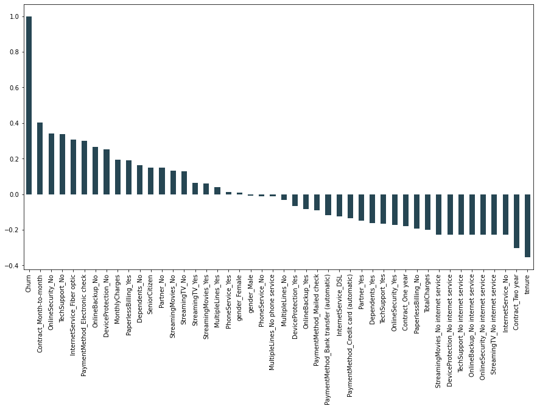

```python
#Checking correlations of the features with Churn

plt.figure(figsize=(15,8))
colors = ['#264653']

cust_final.corr()['Churn'].sort_values(ascending = False).plot(kind = 'bar', color = colors)
```

#### Demographics of the dataset

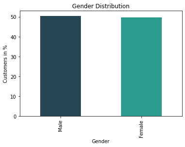

```python
#distribution of gender

colors = ['#264653', '#2a9d8f']

ax = ((cust['gender'].value_counts()/len(cust['gender']))*100).plot(kind = 'bar', color = colors)

ax.set_ylabel('Customers in %')
ax.set_xlabel('Gender')
ax.set_title('Gender Distribution')
```

[output not shown]

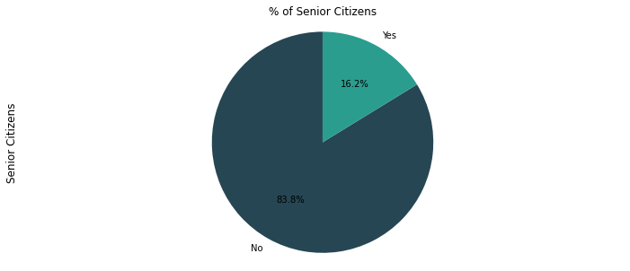

```python
#Distribution of Senior Citizens in the Datset

colors = ['#264653', '#2a9d8f']
mpl.rcParams.update({'text.color' : "black"})
labels = 'No', 'Yes'
plt.figure(figsize = (12,5))
ax = ((cust['SeniorCitizen'].value_counts()/len(cust['SeniorCitizen']))*100).plot.pie(labels=labels, autopct='%1.1f%%', shadow=False, startangle=90, colors = colors)
ax.set_ylabel('Senior Citizens',fontsize = 12)
ax.set_title('% of Senior Citizens', fontsize = 12)
ax.axis('equal')
```

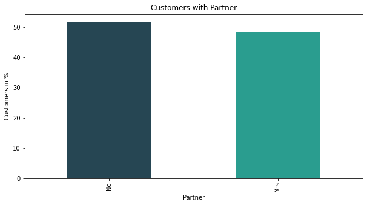

```python
#how many of the customers have a partner and how many dependents?

colors = ['#264653', '#2a9d8f']
plt.figure(figsize = (10,5))

ax = ((cust['Partner'].value_counts()/len(cust['Partner']))*100).plot(kind = 'bar', color = colors)

ax.set_ylabel('Customers in %')
ax.set_xlabel('Partner')
ax.set_title('Customers with Partner')
```

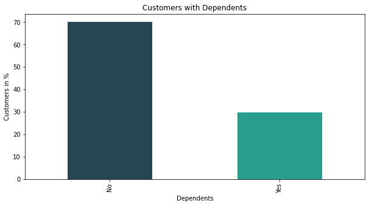

```python
colors = ['#264653', '#2a9d8f']
plt.figure(figsize = (10,5))

ax = ((cust['Dependents'].value_counts()/len(cust['Dependents']))*100).plot(kind = 'bar', color = colors)

ax.set_ylabel('Customers in %')
ax.set_xlabel('Dependents')
ax.set_title('Customers with Dependents')
```

#### Exploring the Contract Types

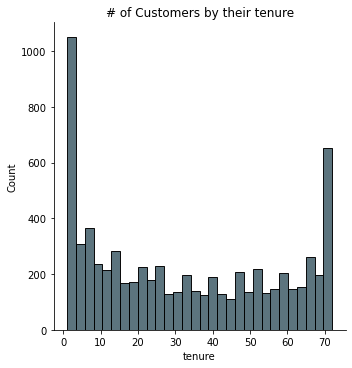

```python
#Distribution of tenure

colors = ['#264653', '#2a9d8f']
sns.set_palette(sns.color_palette(colors))
plt.figure(figsize = (10,5))

ax = sns.displot(cust["tenure"], kde = False, bins = 30)
plt.title('# of Customers by their tenure')
```

We can see that the highest number of customers have a short term tenure. Also a high number of customers has a long term tenure.

This also complies with the distribution of the contract types. Most of the customers have a month-to-month contract or a two-year contract:

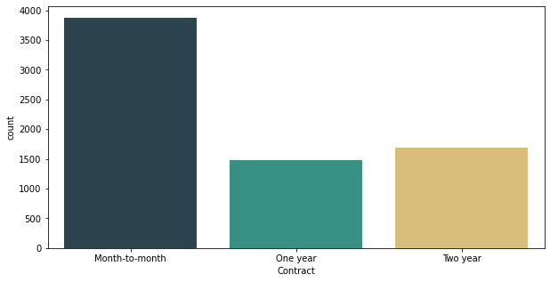

```python
#number of customers by contract type
colors = ['#264653', '#2a9d8f', '#e9c46a', '#f4a261', '#e76f51']
plt.figure(figsize = (10,5))
sns.set_palette(sns.color_palette(colors))

sns.countplot(data = cust, x = 'Contract')
```

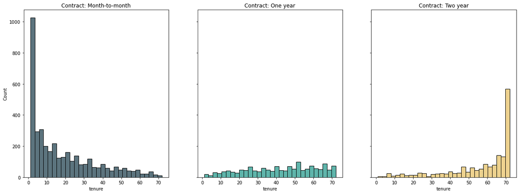

```python
#Tenure by Contract Type

fig, axs = plt.subplots(nrows = 1, ncols = 3, sharey = True, figsize=(20,7))

cols = ['Month-to-month', 'One year', 'Two year']

for i, col in enumerate(cols):
    ax = sns.histplot(cust[cust['Contract'] == col]['tenure'], kde = False, bins = 30, ax = axs[i], color = colors[i])
    ax.set_title('Contract: ' + col)
```

#### Which services are used by the most customers?

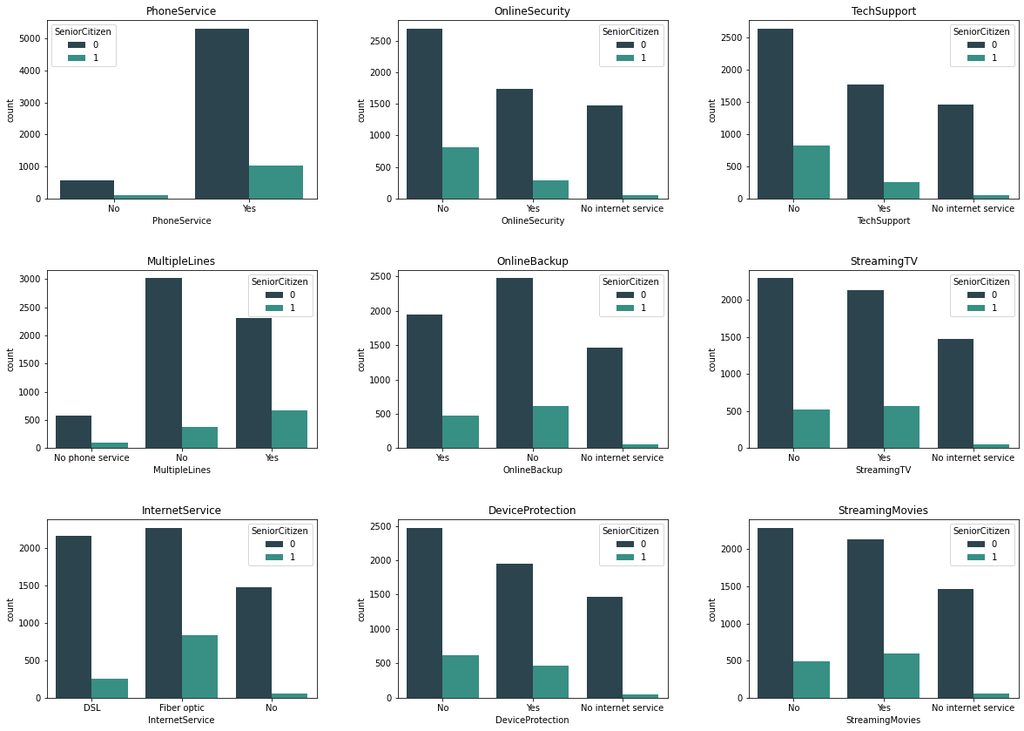

```python
# looking at the services used by the customers
services = ['PhoneService','MultipleLines','InternetService','OnlineSecurity',
           'OnlineBackup','DeviceProtection','TechSupport','StreamingTV','StreamingMovies']

fig, axs = plt.subplots(nrows = 3,ncols = 3,figsize = (20,12))
fig.tight_layout()

left  = 0.125  # the left side of the subplots of the figure
right = 0.9    # the right side of the subplots of the figure
bottom = 0.1   # the bottom of the subplots of the figure
top = 1        # the top of the subplots of the figure
wspace = 0.3   # the amount of width reserved for blank space between subplots
hspace = 0.4   # the amount of height reserved for white space between subplots

plt.subplots_adjust(left, bottom, right, top, wspace, hspace)


for i, service in enumerate(services):
    if(i < 3):
        ax = sns.countplot(data = cust, x = service, hue = 'SeniorCitizen', ax = axs[i,0])
        ax.set_title(service)
    elif(i >= 3 and i < 6):
        ax = sns.countplot(data = cust, x = service, hue = 'SeniorCitizen', ax = axs[i-3,1])
        ax.set_title(service)
    elif(i < 9):
        ax = sns.countplot(data = cust, x = service, hue = 'SeniorCitizen', ax = axs[i-6, 2])
        ax.set_title(service)
```

#### Inspecting the Churn Variable

About 25% of the customers did churn

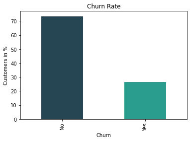

```python
ax = ((cust['Churn'].value_counts()/len(cust['Churn']))*100).plot(kind = 'bar', color = colors)
plt.figure(figsize = (10,5))

ax.set_ylabel('Customers in %')
ax.set_xlabel('Churn')
ax.set_title('Churn Rate')
```

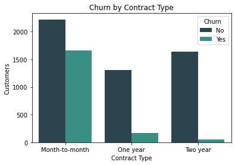

```python
#Churn Rate by contract type

ax = sns.countplot(data = cust, x = 'Contract', hue = 'Churn')

ax.set_ylabel('Customers')
ax.set_xlabel('Contract Type')
ax.set_title('Churn by Contract Type')
```

As we saw at the beginning of the EDA, the contract Type is higly correlated with the probability of churn. Most churn customers purchased a short term month-to-month contract

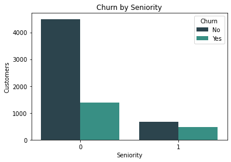

```python
# Churn Rate by seniority

ax = sns.countplot(data = cust, x = 'SeniorCitizen', hue = 'Churn')

ax.set_ylabel('Customers')
ax.set_xlabel('Seniority')
ax.set_title('Churn by Seniority')
```

#### Looking at the Churn rate by charges

Looks like the monthly charges are also an important factor for churn.

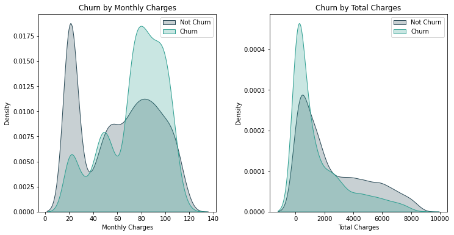

```python
fig, axs = plt.subplots(nrows = 1, ncols = 2, figsize=(12,5))
wspace = 0.3  # the left side of the subplots of the figur
plt.subplots_adjust(left, bottom, right, top, wspace, hspace)



ax = sns.kdeplot(cust.MonthlyCharges[(cust["Churn"] == 'No') ],
                ax = axs[0],shade = True)
ax = sns.kdeplot(cust.MonthlyCharges[(cust["Churn"] == 'Yes') ],
                ax = axs[0], shade= True)

ax.legend(["Not Churn","Churn"],loc='upper right')
ax.set_ylabel('Density')
ax.set_xlabel('Monthly Charges')
ax.set_title('Churn by Monthly Charges')



ax = sns.kdeplot(cust.TotalCharges[(cust["Churn"] == 'No') ],
                ax = axs[1],shade = True)
ax = sns.kdeplot(cust.TotalCharges[(cust["Churn"] == 'Yes') ],
                ax = axs[1], shade= True)

ax.legend(["Not Churn","Churn"],loc='upper right')
ax.set_ylabel('Density')
ax.set_xlabel('Total Charges')
ax.set_title('Churn by Total Charges')
```

### Building models and Prediction

#### 1. Logistic Regression

```python
#starting with prediction
#logisitic regression

X = cust_final.drop('Churn', axis = 1)
y = cust_final['Churn']
features = X.columns.values
```

```python
#scaling the features
from sklearn.preprocessing import MinMaxScaler
scaler = MinMaxScaler(feature_range = (0,1))
scaler.fit(X)
X = pd.DataFrame(scaler.transform(X))
X.columns = features
```

```python
X.head()
```

|  | SeniorCitizen | tenure | MonthlyCharges | TotalCharges | gender_Female | gender_Male | Partner_No | Partner_Yes | Dependents_No | Dependents_Yes | ... | StreamingMovies_Yes | Contract_Month-to-month | Contract_One year | Contract_Two year | PaperlessBilling_No | PaperlessBilling_Yes | PaymentMethod_Bank transfer (automatic) | PaymentMethod_Credit card (automatic) | PaymentMethod_Electronic check | PaymentMethod_Mailed check |
| --- | --- | --- | --- | --- | --- | --- | --- | --- | --- | --- | --- | --- | --- | --- | --- | --- | --- | --- | --- | --- | --- |
| 0 | 0.0 | 0.000000 | 0.115423 | 0.001275 | 1.0 | 0.0 | 0.0 | 1.0 | 1.0 | 0.0 | ... | 0.0 | 1.0 | 0.0 | 0.0 | 0.0 | 1.0 | 0.0 | 0.0 | 1.0 | 0.0 |
| 1 | 0.0 | 0.464789 | 0.385075 | 0.215867 | 0.0 | 1.0 | 1.0 | 0.0 | 1.0 | 0.0 | ... | 0.0 | 0.0 | 1.0 | 0.0 | 1.0 | 0.0 | 0.0 | 0.0 | 0.0 | 1.0 |
| 2 | 0.0 | 0.014085 | 0.354229 | 0.010310 | 0.0 | 1.0 | 1.0 | 0.0 | 1.0 | 0.0 | ... | 0.0 | 1.0 | 0.0 | 0.0 | 0.0 | 1.0 | 0.0 | 0.0 | 0.0 | 1.0 |
| 3 | 0.0 | 0.619718 | 0.239303 | 0.210241 | 0.0 | 1.0 | 1.0 | 0.0 | 1.0 | 0.0 | ... | 0.0 | 0.0 | 1.0 | 0.0 | 1.0 | 0.0 | 1.0 | 0.0 | 0.0 | 0.0 |
| 4 | 0.0 | 0.014085 | 0.521891 | 0.015330 | 1.0 | 0.0 | 1.0 | 0.0 | 1.0 | 0.0 | ... | 0.0 | 1.0 | 0.0 | 0.0 | 0.0 | 1.0 | 0.0 | 0.0 | 1.0 | 0.0 |

5 rows × 45 columns

```python
from sklearn.model_selection import train_test_split
X_train, X_test, y_train, y_test = train_test_split(X, y, test_size=0.3, random_state=101)
```

```python
from sklearn.linear_model import LogisticRegression
from sklearn import metrics
log_reg = LogisticRegression()
log_reg.fit(X_train, y_train)
pred = log_reg.predict(X_test)
```

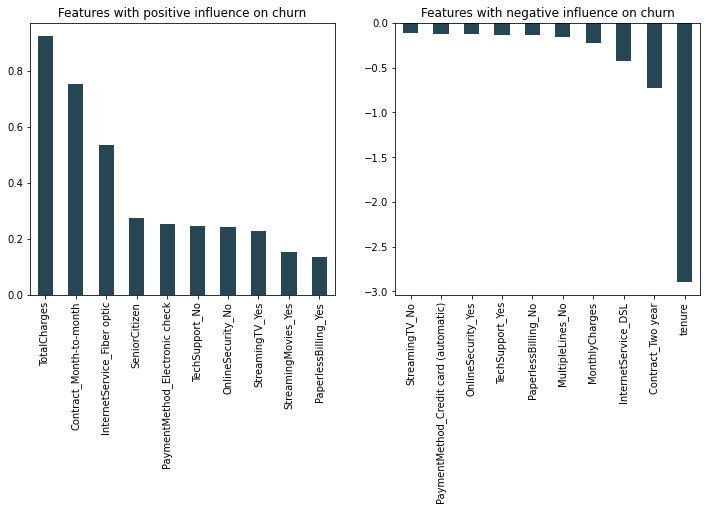

```python
#Values with positive influence on churn
coef = pd.Series(log_reg.coef_[0], index = features)

fig, axs = plt.subplots(nrows = 1, ncols = 2, figsize=(12,5))

ax = coef.sort_values(ascending = False)[:10].plot(kind = 'bar', ax = axs[0])
ax.set_title('Features with positive influence on churn')

ax = coef.sort_values(ascending = False)[-10:].plot(kind = 'bar', ax = axs[1])
ax.set_title('Features with negative influence on churn')
```

```python
print('The Model has an accuarcy of', round(metrics.accuracy_score(y_test, pred)*100, 4), '%')
```

```
The Model has an accuarcy of 80.7583 %
```

#### Findings

- As we already thought during the EDA, the charges and the contract type have a high influence on churn
- Especially the tenure has a negative impact on churn

### Random Forest Classifier

```python
#Building the model
from sklearn.ensemble import RandomForestClassifier

rf_model = RandomForestClassifier(n_estimators = 1000, max_features = "auto", max_leaf_nodes = 30, n_jobs = -1)

rf_model.fit(X_train, y_train)
```

```
RandomForestClassifier(max_leaf_nodes=30, n_estimators=1000, n_jobs=-1)
```

```python
#Making the Predictions
pred = rf_model.predict(X_test)

print('Accuracy of the Model is: ', round(metrics.accuracy_score(y_test, pred)*100, 4), '%')
```

```
Accuracy of the Model is:  81.2322 %
```

```
                                  Weight
Contract_Month-to-month         0.156064
tenure                          0.137638
TotalCharges                    0.096381
TechSupport_No                  0.074403
OnlineSecurity_No               0.072248
InternetService_Fiber optic     0.067285
MonthlyCharges                  0.056216
PaymentMethod_Electronic check  0.047970
Contract_Two year               0.045590
InternetService_DSL             0.025383
```

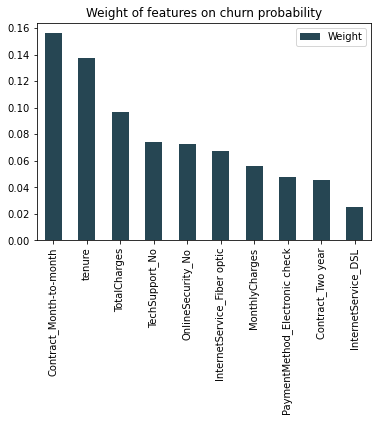

```python
imp = rf_model.feature_importances_

weights = pd.DataFrame(imp, index=X.columns.values, columns = ['Weight'])

print(weights.sort_values(by ="Weight", ascending = False).head(10))


ax = weights.sort_values(by ="Weight", ascending = False)[:10].plot(kind = 'bar')

ax.set_title('Weight of features on churn probability')
```

#### Findings

- We get a similiar but slightly more accurate result from the Randomforest Classifier
- The importance of contract type and tenure for churn probability gets even more emphasized

### XGBoost

Using XGBoost get a additional reference

```python
# Building the model

from xgboost import XGBClassifier

xgb_model = XGBClassifier()

xgb_model.fit(X_train, y_train)
```

```
XGBClassifier(base_score=0.5, booster='gbtree', callbacks=None,
              colsample_bylevel=1, colsample_bynode=1, colsample_bytree=1,
              early_stopping_rounds=None, enable_categorical=False,
              eval_metric=None, gamma=0, gpu_id=-1, grow_policy='depthwise',
              importance_type=None, interaction_constraints='',
              learning_rate=0.300000012, max_bin=256, max_cat_to_onehot=4,
              max_delta_step=0, max_depth=6, max_leaves=0, min_child_weight=1,
              missing=nan, monotone_constraints='()', n_estimators=100,
              n_jobs=0, num_parallel_tree=1, predictor='auto', random_state=0,
              reg_alpha=0, reg_lambda=1, ...)
```

```python
#Making predictions

pred = xgb_model.predict(X_test)

print('Accuracy of the Model is: ', round(metrics.accuracy_score(y_test, pred)*100, 4), '%')
```

```
Accuracy of the Model is:  79.7156 %
```

- With the XGB Model we recieved the worst predicitions so far
- The best model seems to be the Random Forest Classifier

#### Thanks for having a look at my notebook!